## Khoi Tran - s4664074

# Assignment 2

### 1. Display the first 10 rows of the dataset using `kable()` function

```r
#Loading library
library(tidyverse)
library(skimr)
library(randomForest)
library(knitr)
library(scales)
library(lubridate)
library(widyr)
#Import dataset
meals <- read_csv("https://raw.githubusercontent.com/rfordatascience/tidytuesday/master/data/2018/2018-11-20/thanksgiving_meals.csv")
kable(meals[1:10,])
```

| id | celebrate | main_dish | main_dish_other | main_prep | main_prep_other | stuffing | stuffing_other | cranberry | cranberry_other | gravy | side1 | side2 | side3 | side4 | side5 | side6 | side7 | side8 | side9 | side10 | side11 | side12 | side13 | side14 | side15 | pie1 | pie2 | pie3 | pie4 | … |
| --- | --- | --- | --- | --- | --- | --- | --- | --- | --- | --- | --- | --- | --- | --- | --- | --- | --- | --- | --- | --- | --- | --- | --- | --- | --- | --- | --- | --- | --- | --- |
| 4337954960 | Yes | Turkey | NA | Baked | NA | Bread-based | NA | None | NA | Yes | NA | Carrots | NA | NA | NA | NA | Green beans/green bean casserole | Macaroni and cheese | Mashed potatoes | NA | NA | NA | Yams/sweet potato casserole | NA | NA | Apple | NA | NA | NA | … |
| 4337951949 | Yes | Turkey | NA | Baked | NA | Bread-based | NA | Other (please specify) | Homemade cranberry gelatin ring | Yes | NA | NA | NA | Corn | NA | NA | Green beans/green bean casserole | Macaroni and cheese | Mashed potatoes | Rolls/biscuits | NA | Vegetable salad | Yams/sweet potato casserole | Other (please specify) | Asian vinagrette salad | Apple | NA | NA | Chocolate | … |
| 4337935621 | Yes | Turkey | NA | Roasted | NA | Rice-based | NA | Homemade | NA | Yes | Brussel sprouts | Carrots | Cauliflower | Corn | Cornbread | NA | NA | NA | Mashed potatoes | Rolls/biscuits | NA | Vegetable salad | NA | NA | NA | Apple | NA | Cherry | NA | … |
| 4337933040 | Yes | Turkey | NA | Baked | NA | Bread-based | NA | Homemade | NA | Yes | Brussel sprouts | NA | NA | NA | Cornbread | NA | NA | NA | Mashed potatoes | Rolls/biscuits | NA | Vegetable salad | Yams/sweet potato casserole | NA | NA | NA | NA | NA | NA | … |
| 4337931983 | Yes | Tofurkey | NA | Baked | NA | Bread-based | NA | Canned | NA | Yes | Brussel sprouts | NA | NA | NA | Cornbread | NA | NA | NA | Mashed potatoes | Rolls/biscuits | Squash | Vegetable salad | Yams/sweet potato casserole | NA | NA | Apple | NA | NA | NA | … |
| 4337929779 | Yes | Turkey | NA | Roasted | NA | Rice-based | NA | Homemade | NA | Yes | Brussel sprouts | Carrots | Cauliflower | Corn | Cornbread | Fruit salad | Green beans/green bean casserole | Macaroni and cheese | Mashed potatoes | Rolls/biscuits | Squash | Vegetable salad | Yams/sweet potato casserole | NA | NA | NA | NA | NA | NA | … |
| 4337924420 | Yes | Turkey | NA | Baked | NA | Bread-based | NA | Canned | NA | Yes | NA | NA | NA | NA | NA | Fruit salad | Green beans/green bean casserole | NA | Mashed potatoes | Rolls/biscuits | NA | NA | Yams/sweet potato casserole | NA | NA | Apple | NA | NA | NA | … |
| 4337916002 | Yes | Turkey | NA | Baked | NA | Rice-based | NA | Homemade | NA | Yes | NA | Carrots | NA | NA | NA | NA | NA | NA | NA | NA | NA | NA | NA | NA | NA | NA | NA | NA | Chocolate | … |
| 4337914977 | Yes | Turkey | NA | Roasted | NA | Bread-based | NA | Canned | NA | Yes | Brussel sprouts | NA | NA | Corn | Cornbread | NA | Green beans/green bean casserole | NA | Mashed potatoes | Rolls/biscuits | Squash | NA | NA | NA | NA | Apple | Buttermilk | NA | NA | … |
| 4337899817 | Yes | Other (please specify) | Turkey and Ham | Baked | NA | Bread-based | NA | Other (please specify) | Both Canned and Homemade | Yes | Brussel sprouts | Carrots | NA | NA | NA | NA | Green beans/green bean casserole | NA | Mashed potatoes | Rolls/biscuits | NA | NA | Yams/sweet potato casserole | NA | NA | NA | Buttermilk | NA | NA | … |

### 2. Using `skim()` display the summary of variables. Think about the task to predict a family income based on their menu: what variables may be useful? Are all of them correct type? Write 2-3 sentences with your explanation. (2 marks)

```r
skim(meals)
```

Data summary

| Name | meals |
| --- | --- |
| Number of rows | 1058 |
| Number of columns | 65 |
| _______________________ |  |
| Column type frequency: |  |
| character | 64 |
| numeric | 1 |
| ________________________ |  |
| Group variables | None |

**Variable type: character**

| skim_variable | n_missing | complete_rate | min | max | empty | n_unique | whitespace |
| --- | --- | --- | --- | --- | --- | --- | --- |
| celebrate | 0 | 1.00 | 2 | 3 | 0 | 2 | 0 |
| main_dish | 84 | 0.92 | 6 | 22 | 0 | 8 | 0 |
| main_dish_other | 1023 | 0.03 | 4 | 85 | 0 | 32 | 0 |
| main_prep | 84 | 0.92 | 5 | 22 | 0 | 5 | 0 |
| main_prep_other | 1007 | 0.05 | 1 | 33 | 0 | 32 | 0 |
| stuffing | 84 | 0.92 | 4 | 22 | 0 | 4 | 0 |
| stuffing_other | 1022 | 0.03 | 4 | 46 | 0 | 29 | 0 |
| cranberry | 84 | 0.92 | 4 | 22 | 0 | 4 | 0 |
| cranberry_other | 1033 | 0.02 | 3 | 61 | 0 | 24 | 0 |
| gravy | 84 | 0.92 | 2 | 3 | 0 | 2 | 0 |
| side1 | 903 | 0.15 | 15 | 15 | 0 | 1 | 0 |
| side2 | 816 | 0.23 | 7 | 7 | 0 | 1 | 0 |
| side3 | 970 | 0.08 | 11 | 11 | 0 | 1 | 0 |
| side4 | 594 | 0.44 | 4 | 4 | 0 | 1 | 0 |
| side5 | 823 | 0.22 | 9 | 9 | 0 | 1 | 0 |
| side6 | 843 | 0.20 | 11 | 11 | 0 | 1 | 0 |
| side7 | 372 | 0.65 | 32 | 32 | 0 | 1 | 0 |
| side8 | 852 | 0.19 | 19 | 19 | 0 | 1 | 0 |
| side9 | 241 | 0.77 | 15 | 15 | 0 | 1 | 0 |
| side10 | 292 | 0.72 | 14 | 14 | 0 | 1 | 0 |
| side11 | 887 | 0.16 | 6 | 6 | 0 | 1 | 0 |
| side12 | 849 | 0.20 | 15 | 15 | 0 | 1 | 0 |
| side13 | 427 | 0.60 | 27 | 27 | 0 | 1 | 0 |
| side14 | 947 | 0.10 | 22 | 22 | 0 | 1 | 0 |
| side15 | 947 | 0.10 | 4 | 78 | 0 | 89 | 0 |
| pie1 | 544 | 0.49 | 5 | 5 | 0 | 1 | 0 |
| pie2 | 1023 | 0.03 | 10 | 10 | 0 | 1 | 0 |
| pie3 | 945 | 0.11 | 6 | 6 | 0 | 1 | 0 |
| pie4 | 925 | 0.13 | 9 | 9 | 0 | 1 | 0 |
| pie5 | 1022 | 0.03 | 13 | 13 | 0 | 1 | 0 |
| pie6 | 1019 | 0.04 | 8 | 8 | 0 | 1 | 0 |
| pie7 | 1024 | 0.03 | 5 | 5 | 0 | 1 | 0 |
| pie8 | 716 | 0.32 | 5 | 5 | 0 | 1 | 0 |
| pie9 | 329 | 0.69 | 7 | 7 | 0 | 1 | 0 |
| pie10 | 906 | 0.14 | 12 | 12 | 0 | 1 | 0 |
| pie11 | 1018 | 0.04 | 4 | 4 | 0 | 1 | 0 |
| pie12 | 987 | 0.07 | 22 | 22 | 0 | 1 | 0 |
| pie13 | 987 | 0.07 | 5 | 46 | 0 | 61 | 0 |
| dessert1 | 948 | 0.10 | 13 | 13 | 0 | 1 | 0 |
| dessert2 | 1042 | 0.02 | 8 | 8 | 0 | 1 | 0 |
| dessert3 | 930 | 0.12 | 8 | 8 | 0 | 1 | 0 |
| dessert4 | 986 | 0.07 | 11 | 11 | 0 | 1 | 0 |
| dessert5 | 867 | 0.18 | 10 | 10 | 0 | 1 | 0 |
| dessert6 | 854 | 0.19 | 7 | 7 | 0 | 1 | 0 |
| dessert7 | 1015 | 0.04 | 5 | 5 | 0 | 1 | 0 |
| dessert8 | 792 | 0.25 | 9 | 9 | 0 | 1 | 0 |
| dessert9 | 955 | 0.10 | 13 | 13 | 0 | 1 | 0 |
| dessert10 | 763 | 0.28 | 4 | 4 | 0 | 1 | 0 |
| dessert11 | 924 | 0.13 | 22 | 22 | 0 | 1 | 0 |
| dessert12 | 924 | 0.13 | 3 | 59 | 0 | 92 | 0 |
| prayer | 99 | 0.91 | 2 | 3 | 0 | 2 | 0 |
| travel | 107 | 0.90 | 59 | 80 | 0 | 4 | 0 |
| watch_program | 556 | 0.47 | 13 | 13 | 0 | 1 | 0 |
| kids_table_age | 107 | 0.90 | 2 | 13 | 0 | 12 | 0 |
| hometown_friends | 107 | 0.90 | 2 | 3 | 0 | 2 | 0 |
| friendsgiving | 107 | 0.90 | 2 | 3 | 0 | 2 | 0 |
| black_friday | 107 | 0.90 | 2 | 3 | 0 | 2 | 0 |
| work_retail | 107 | 0.90 | 2 | 3 | 0 | 2 | 0 |
| work_black_friday | 988 | 0.07 | 2 | 13 | 0 | 3 | 0 |
| community_type | 110 | 0.90 | 5 | 8 | 0 | 3 | 0 |
| age | 33 | 0.97 | 3 | 7 | 0 | 4 | 0 |
| gender | 33 | 0.97 | 4 | 6 | 0 | 2 | 0 |
| family_income | 33 | 0.97 | 12 | 20 | 0 | 11 | 0 |
| us_region | 59 | 0.94 | 7 | 18 | 0 | 9 | 0 |

**Variable type: numeric**

| skim_variable | n_missing | complete_rate | mean | sd | p0 | p25 | p50 | p75 | p100 | hist |
| --- | --- | --- | --- | --- | --- | --- | --- | --- | --- | --- |
| id | 0 | 1 | 4336731188 | 493783.4 | 4335894916 | 4336339486 | 4336796628 | 4337012140 | 4337954960 | ▅▃▇▂▂ |

```r
# To predict a family income (numeric variable) based on their menu, we could use "age" variable or "kids_table_age" variable to predict "family_income" variable. All of them are character type, so we will need to transform them into numeric type.

# TO predict a community type or US_region (category variables) based on their menu, we could use different variables such as "main_dish", "celebrate", "main_prep", "gender", "age", "family_income", "kids_table_age". All of them are character type, which we can transform them into category type.
```

### 3. Use `fct_reorder` and `parse_number` functions to create a factor variable `family_income`

```r
meals_income_factor <- meals %>%
  filter(!is.na(family_income) & family_income != "Prefer not to answer") %>%
  mutate(family_income = fct_reorder(as_factor(family_income), parse_number(family_income)))

class(meals_income_factor$family_income)
```

```
## [1] "factor"
```

### 4. What is the number of people who celebrate?

```r
meals %>% count(celebrate)
```

```
## # A tibble: 2 x 2
##   celebrate     n
##   <chr>     <int>
## 1 No           78
## 2 Yes         980
```

```r
#There are 980 people who celebrate thanksgiving
```

### 5. What are categories and insights for each main dish served and the method it is prepared?

```r
meals %>% count(main_dish, main_prep, sort = TRUE)
```

```
## # A tibble: 31 x 3
##    main_dish              main_prep                  n
##    <chr>                  <chr>                  <int>
##  1 Turkey                 Baked                    422
##  2 Turkey                 Roasted                  351
##  3 <NA>                   <NA>                      84
##  4 Turkey                 Fried                     41
##  5 Turkey                 Other (please specify)    34
##  6 Ham/Pork               Baked                     22
##  7 Other (please specify) Baked                     16
##  8 Tofurkey               Baked                     14
##  9 Other (please specify) Other (please specify)    12
## 10 Turkey                 I don't know              11
## # ... with 21 more rows
```

```r
# If there is no main dish, there would be no main prep as well

meals_main <- meals %>%
  filter( main_dish != "I don't know" & #unidentified variable
          main_dish != "Tofurkey" &     #mistype
          main_dish != "Turducken" &    #mistype
          main_prep != "I don't know" &
          !is.na(main_dish) &
          !is.na(main_prep))

meals_main %>% count(main_dish, sort = TRUE)
```

```
## # A tibble: 5 x 2
##   main_dish                  n
##   <chr>                  <int>
## 1 Turkey                   848
## 2 Other (please specify)    34
## 3 Ham/Pork                  28
## 4 Chicken                   12
## 5 Roast beef                11
```

```r
meals_main %>% count(main_prep, sort = TRUE)
```

```
## # A tibble: 4 x 2
##   main_prep                  n
##   <chr>                  <int>
## 1 Baked                    467
## 2 Roasted                  370
## 3 Other (please specify)    50
## 4 Fried                     46
```

```r
# There are four main dishes (Turkey, Ham/Pork, Chicken, Roast beef) during Thanksgiving, in which they can be mainly prepared in three different ways (Baked, Roasted, Fried).
```

### 6. Create 3 different data viz showing insights for main dish served and the method. Provide your own legend and use themes.

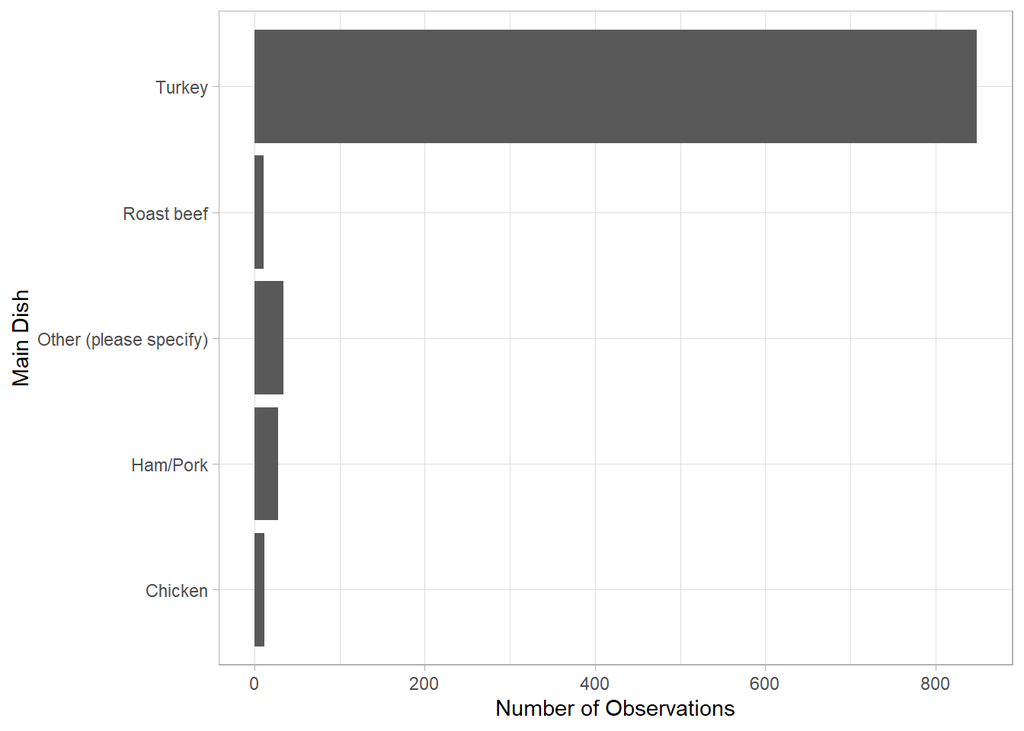

```r
theme_set(theme_light())

meals_main %>% ggplot(
  aes(main_dish)
)+
  geom_bar() +
  coord_flip() +
  labs(x="Main Dish", y="Number of Observations")
```

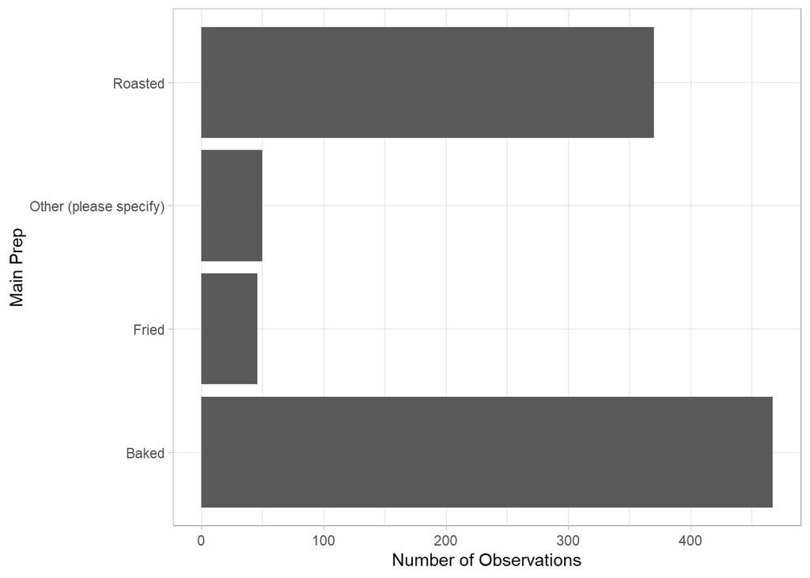

```r
#Out of 5 categories, the graph indicates that Turkey is the most popular main dish during thanksgiving with over 750 observations while chicken and roast beef are the least favorite

meals_main %>% ggplot(
  aes(x=main_prep)
)+
  geom_bar() +
  coord_flip() +
  labs(x="Main Prep", y="Number of Observations")
```

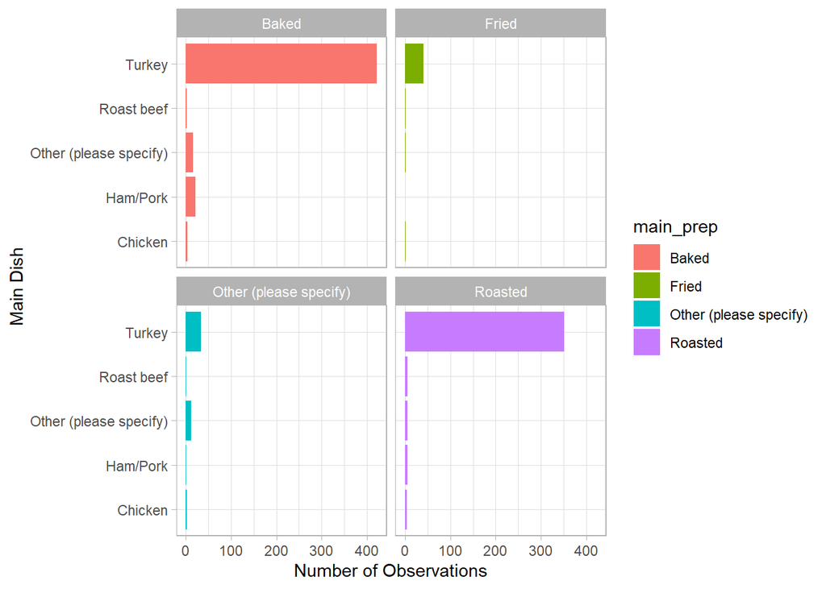

```r
#Out of 4 categories, the graph indicates that baking is the most favorite preparation method for main dish, following that is the roasting method

meals_main %>%
  group_by(main_dish, main_prep) %>%
  summarise(n=n()) %>%
  ungroup() %>%
  ggplot(
    aes(x=main_dish,
        y=n,
        fill=main_prep)
  )+
  geom_col() +
  labs(x="Main Dish", y="Number of Observations") +
  coord_flip()+
  facet_wrap(~main_prep, nrow=2)
```

```r
# For Turkey dish, most people prefer baking rather that roasting, Some people also enjoy fried turkey or they choose different methods for preparation
```